# Week7 Tutorial - Regularized Regression

13/3/2021

```r
# Import libraries
library(tidyverse)
library(DataExplorer)
library(VIM)
library(mice)
library(missForest)
# Sampling, cross validation
library(caret)
library(psych)
library(reshape2)
library(ROCR)
library(naivebayes)
# Regression models
library(glmnet)
library(mlbench)
library(ggplot2)
# Plotting coeffs
library(broom)
```

## 1. Dataset Description

### 1.1 General Information

#### Data Set: https://www.kaggle.com/sajidsaifi/prostate-cancer

#### Reference: https://www.kaggle.com/smogomes/prostate-cancer-prediction-model/notebook

- Feature number: 9
- Instance number: 100

### 1.2 Independent Variables

1. Radius (Continuous variable).
2. Texture (Continuous variable).
3. Perimeter (Continuous variable).
4. Area (Continuous variable).
5. Smoothness (Continuous variable).
6. Compactness (Continuous variable).
7. Symmetry (Continuous variable).
8. Fractal (Continuous variable).

### 1.3 Dependent Variables

1. Diagnosis result (Categorical variable): M (1), B (0).

```r
# Load data
df <- read.csv('Prostate_Cancer.csv', header = T)
```

## 2. Dataset Overview

```r
summary(df)
```

```
       id         diagnosis_result       radius         texture        perimeter
 Min.   :  1.00   Length:100         Min.   : 9.00   Min.   :11.00   Min.   : 52.00
 1st Qu.: 25.75   Class :character   1st Qu.:12.00   1st Qu.:14.00   1st Qu.: 82.50
 Median : 50.50   Mode  :character   Median :17.00   Median :17.50   Median : 94.00
 Mean   : 50.50                      Mean   :16.85   Mean   :18.23   Mean   : 96.78
 3rd Qu.: 75.25                      3rd Qu.:21.00   3rd Qu.:22.25   3rd Qu.:114.25
 Max.   :100.00                      Max.   :25.00   Max.   :27.00   Max.   :172.00
      area          smoothness      compactness        symmetry      fractal_dimension
 Min.   : 202.0   Min.   :0.0700   Min.   :0.0380   Min.   :0.1350   Min.   :0.05300
 1st Qu.: 476.8   1st Qu.:0.0935   1st Qu.:0.0805   1st Qu.:0.1720   1st Qu.:0.05900
 Median : 644.0   Median :0.1020   Median :0.1185   Median :0.1900   Median :0.06300
 Mean   : 702.9   Mean   :0.1027   Mean   :0.1267   Mean   :0.1932   Mean   :0.06469
 3rd Qu.: 917.0   3rd Qu.:0.1120   3rd Qu.:0.1570   3rd Qu.:0.2090   3rd Qu.:0.06900
 Max.   :1878.0   Max.   :0.1430   Max.   :0.3450   Max.   :0.3040   Max.   :0.09700
```

```r
# Dataset info
str(df)
```

```
'data.frame':   100 obs. of  10 variables:
 $ id               : int  1 2 3 4 5 6 7 8 9 10 ...
 $ diagnosis_result : chr  "M" "B" "M" "M" ...
 $ radius           : int  23 9 21 14 9 25 16 15 19 25 ...
 $ texture          : int  12 13 27 16 19 25 26 18 24 11 ...
 $ perimeter        : int  151 133 130 78 135 83 120 90 88 84 ...
 $ area             : int  954 1326 1203 386 1297 477 1040 578 520 476 ...
 $ smoothness       : num  0.143 0.143 0.125 0.07 0.141 0.128 0.095 0.119 0.127 0.119 ...
 $ compactness      : num  0.278 0.079 0.16 0.284 0.133 0.17 0.109 0.165 0.193 0.24 ...
 $ symmetry         : num  0.242 0.181 0.207 0.26 0.181 0.209 0.179 0.22 0.235 0.203 ...
 $ fractal_dimension: num  0.079 0.057 0.06 0.097 0.059 0.076 0.057 0.075 0.074 0.082 ...
```

## 4. Data Imputation

```r
# Prior to treating missing values any blanks in the data set must be converted to NA.
df <- mutate_all(df, na_if, "")
```

### 4.1 Plot Missing Values

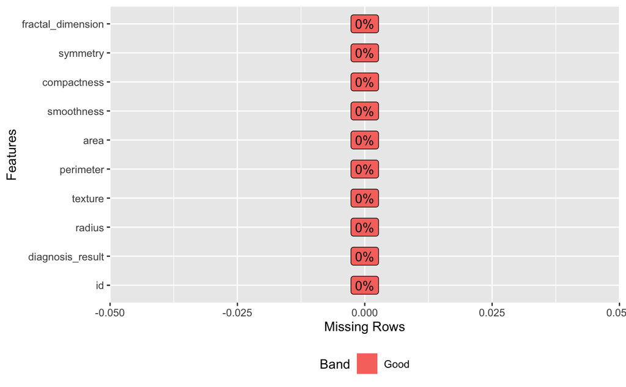

```r
# Viewing and counting missing data using DataExplorer package.
plot_missing(df)
```

Good News, there is no missing value now.

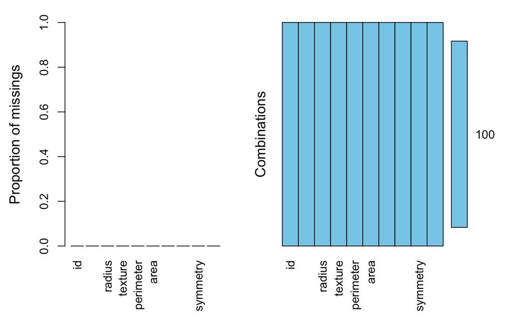

```r
# Using VIM library
vim_plot <- aggr(df, numbers=TRUE, prop = c(TRUE, FALSE))
```

As we can see, we have 100 records in total, and no missing value in this data set.

This function plots and calculates the amount of missing values in each variable and in certain combinations. On the right-hand chart, we can see the missing values’ distribution in a combination. Notice that left-hand chart uses proportions as Y-axis, while the right one uses real number because we set prop = c(TRUE, FALSE).

```
 /\     /\
{  `---'  }
{  O   O  }
==>  V <==  No need for mice. This data set is completely observed.
 \  \|/  /
  `-----'

    id diagnosis_result radius texture perimeter area smoothness compactness symmetry
100  1                1      1       1         1    1          1           1        1
     0                0      0       0         0    0          0           0        0
    fractal_dimension
100                 1 0
                    0 0
```

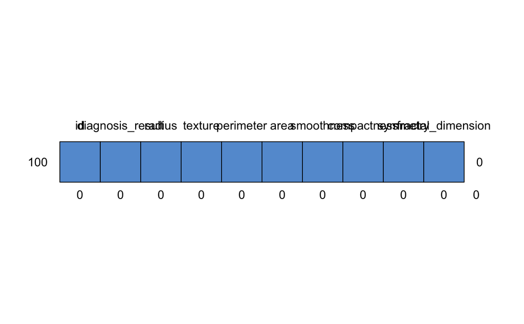

```r
# Using mice library
md.pattern(df)
```

This chart demonstrates the distribution of missing values. The values on the left side represent different groups of the data set. The values on the right side represent the total number of variables that contain missing value. The top line are names of different variables. The bottom line represents the number of missing values of each variable.

```r
# Overview of new data set
sum(is.na(df))
```

```
[1] 0
```

```r
head(df, 10)
```

|  | id | diagnosis_result | radius | texture | perimeter | area | smoothness | compactness | symmetry | fractal_dimension |
| --- | --- | --- | --- | --- | --- | --- | --- | --- | --- | --- |
| 1 | 1 | M | 23 | 12 | 151 | 954 | 0.143 | 0.278 | 0.242 | 0.079 |
| 2 | 2 | B | 9 | 13 | 133 | 1326 | 0.143 | 0.079 | 0.181 | 0.057 |
| 3 | 3 | M | 21 | 27 | 130 | 1203 | 0.125 | 0.160 | 0.207 | 0.060 |
| 4 | 4 | M | 14 | 16 | 78 | 386 | 0.070 | 0.284 | 0.260 | 0.097 |
| 5 | 5 | M | 9 | 19 | 135 | 1297 | 0.141 | 0.133 | 0.181 | 0.059 |
| 6 | 6 | B | 25 | 25 | 83 | 477 | 0.128 | 0.170 | 0.209 | 0.076 |
| 7 | 7 | M | 16 | 26 | 120 | 1040 | 0.095 | 0.109 | 0.179 | 0.057 |
| 8 | 8 | M | 15 | 18 | 90 | 578 | 0.119 | 0.165 | 0.220 | 0.075 |
| 9 | 9 | M | 19 | 24 | 88 | 520 | 0.127 | 0.193 | 0.235 | 0.074 |
| 10 | 10 | M | 25 | 11 | 84 | 476 | 0.119 | 0.240 | 0.203 | 0.082 |

## 5. Data Analyze

### 5.1 Distribution of diagnosis results

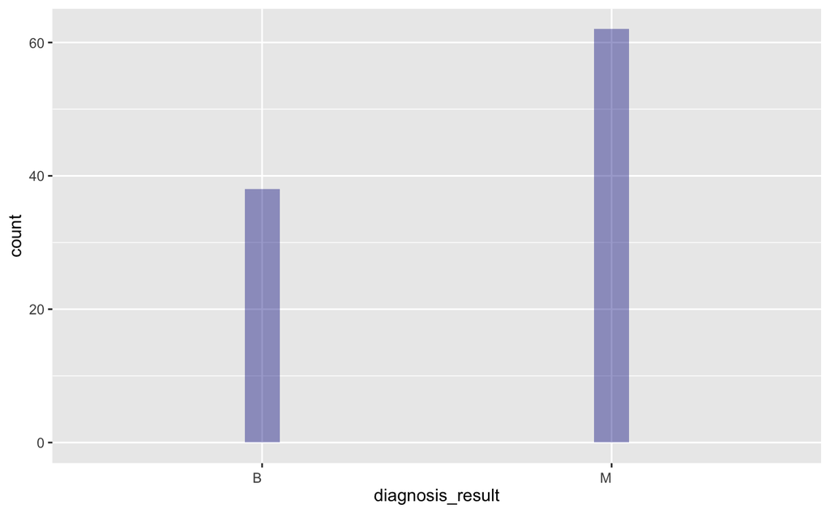

```r
ggplot(df, aes(x=diagnosis_result), color="darkblue") +
  geom_histogram(stat='count', aes(y = ..count..), width=.1, fill="darkblue", alpha=0.4) +
  theme(axis.text.x=element_text(angle=0, hjust=1, vjust=.5))
```

### 5.2 Distribution of the dependent variable.

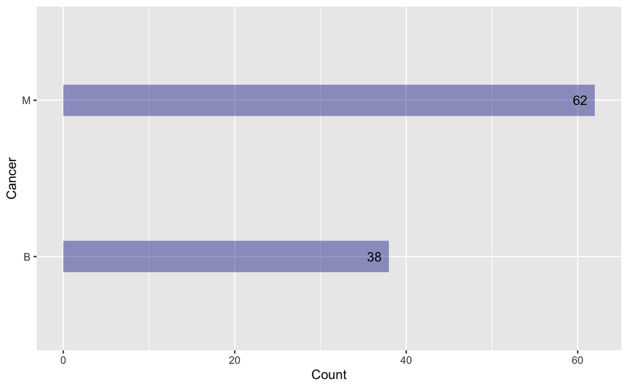

```r
ggplot(df, aes(y = diagnosis_result)) +
  geom_bar(width=.2, fill="darkblue", alpha=0.4) +
  xlab("Count") +
  ylab("Cancer") +
  geom_text(stat='count', aes(label=..count..), hjust=1.5, vjust=.5)
```

[figure not shown]

```r
barplot(table(df$diagnosis_result),
        xlab="Class (M = Benign, B = Malignant)", ylab="Count", col=c("darkblue","red"),
        legend = levels(df$diagnosis_result), beside=TRUE)
```

## 6. Feature Selection

### 6.1 Correlation matrix

```r
df.cor <- df %>%
      mutate(diagnosis_result = ifelse(diagnosis_result == "B", 0, 1))
str(df.cor)
```

```
'data.frame':   100 obs. of  10 variables:
 $ id               : int  1 2 3 4 5 6 7 8 9 10 ...
 $ diagnosis_result : num  1 0 1 1 1 0 1 1 1 1 ...
 $ radius           : int  23 9 21 14 9 25 16 15 19 25 ...
 $ texture          : int  12 13 27 16 19 25 26 18 24 11 ...
 $ perimeter        : int  151 133 130 78 135 83 120 90 88 84 ...
 $ area             : int  954 1326 1203 386 1297 477 1040 578 520 476 ...
 $ smoothness       : num  0.143 0.143 0.125 0.07 0.141 0.128 0.095 0.119 0.127 0.119 ...
 $ compactness      : num  0.278 0.079 0.16 0.284 0.133 0.17 0.109 0.165 0.193 0.24 ...
 $ symmetry         : num  0.242 0.181 0.207 0.26 0.181 0.209 0.179 0.22 0.235 0.203 ...
 $ fractal_dimension: num  0.079 0.057 0.06 0.097 0.059 0.076 0.057 0.075 0.074 0.082 ...
```

```r
cormat <- round(cor(select(df.cor, c("diagnosis_result", "radius", "texture", "perimeter", "area", "smoothness", "compactness", "symmetry", "fractal_dimension"))), 3)
# Merge data
melted_cormat = melt(cormat)
```

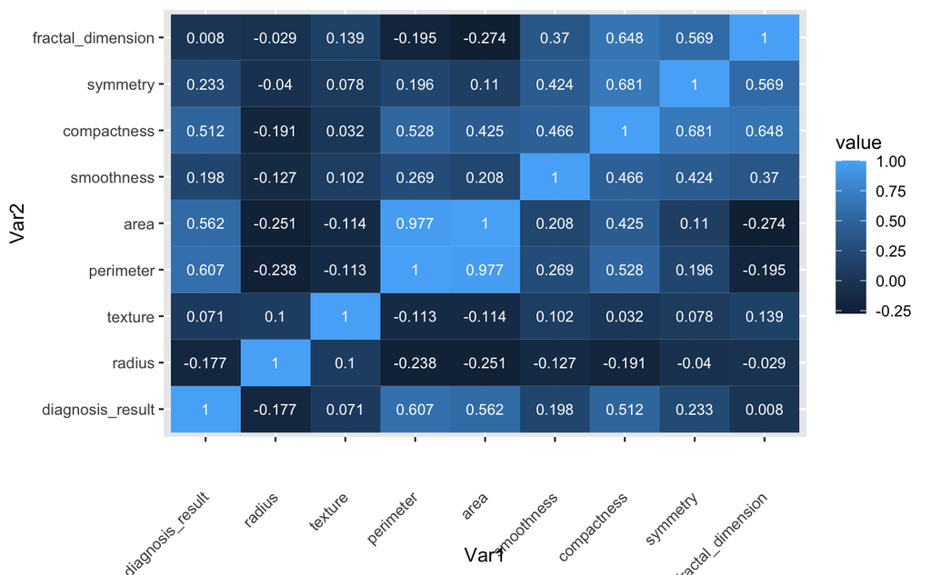

```r
ggplot(data=melted_cormat, aes(x=Var1, y=Var2, fill=value)) +
  geom_tile() +
  theme(axis.text.x=element_text(angle=45, hjust=1, vjust=.5)) +
  geom_text(aes(Var2, Var1, label = value),color='white', size=3)
```

```r
df.cor = subset(df.cor, select = -c(id, fractal_dimension, texture, perimeter) )
str(df.cor)
```

```
'data.frame':   100 obs. of  6 variables:
 $ diagnosis_result: num  1 0 1 1 1 0 1 1 1 1 ...
 $ radius          : int  23 9 21 14 9 25 16 15 19 25 ...
 $ area            : int  954 1326 1203 386 1297 477 1040 578 520 476 ...
 $ smoothness      : num  0.143 0.143 0.125 0.07 0.141 0.128 0.095 0.119 0.127 0.119 ...
 $ compactness     : num  0.278 0.079 0.16 0.284 0.133 0.17 0.109 0.165 0.193 0.24 ...
 $ symmetry        : num  0.242 0.181 0.207 0.26 0.181 0.209 0.179 0.22 0.235 0.203 ...
```

### 6.2 Check Gaussianness

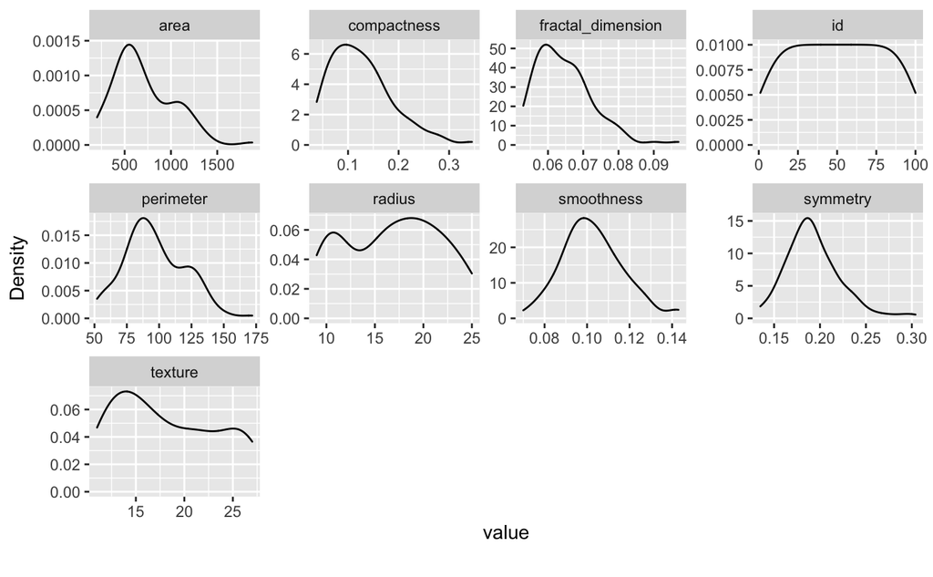

```r
# Check if the density plot os Gaussian
plot_density(df)
```

## 7. Data Normalization

```r
# Normalization
min_max_norm <- function(x) {
      (x - min(x)) / (max(x) - min(x))
}
df.norm = df.cor
df.norm[2:6] <- as.data.frame(lapply(df.cor[2:6], min_max_norm))
```

```r
sum(is.na(df))
```

```
[1] 0
```

```r
summary(df.norm)
```

```
 diagnosis_result     radius            area          smoothness      compactness
 Min.   :0.00     Min.   :0.0000   Min.   :0.0000   Min.   :0.0000   Min.   :0.0000
 1st Qu.:0.00     1st Qu.:0.1875   1st Qu.:0.1639   1st Qu.:0.3219   1st Qu.:0.1384
 Median :1.00     Median :0.5000   Median :0.2637   Median :0.4384   Median :0.2622
 Mean   :0.62     Mean   :0.4906   Mean   :0.2989   Mean   :0.4484   Mean   :0.2889
 3rd Qu.:1.00     3rd Qu.:0.7500   3rd Qu.:0.4266   3rd Qu.:0.5753   3rd Qu.:0.3876
 Max.   :1.00     Max.   :1.0000   Max.   :1.0000   Max.   :1.0000   Max.   :1.0000
    symmetry
 Min.   :0.0000
 1st Qu.:0.2189
 Median :0.3254
 Mean   :0.3442
 3rd Qu.:0.4379
 Max.   :1.0000
```

```r
# df.norm = df.norm %>% mutate(value = 1)  %>% spread(diagnosis_result, value,  fill = 0 )
# head(df.norm)
```

## 8. Data Set Partitioning

We use 80% of the data set for training, and the rest for testing.

```r
# 80% of the sample size
smp_size <- floor(0.80 * nrow(df))
set.seed(123)
train_ind <- sample(seq_len(nrow(df.norm)), size=smp_size)
train <- df.norm[train_ind, ]
test <- df.norm[-train_ind, ]
```

## 9. Experiments

### 9.1 Baseline Linear regression

#### In regression with a single independent variable, the coefficient tells you how much the dependent variable is expected to increase (if the coefficient is positive) or decrease (if the coefficient is negative) when that independent variable increases by one.

(ref: https://dss.princeton.edu/online_help/analysis/interpreting_regression.htm)

```r
l_baseline <- glm(formula = diagnosis_result ~ . , data = train)
summary(l_baseline)
```

```
Call:
glm(formula = diagnosis_result ~ ., data = train)

Deviance Residuals:
     Min        1Q    Median        3Q       Max
-1.14623  -0.28175   0.00604   0.28215   0.70796

Coefficients:
            Estimate Std. Error t value Pr(>|t|)
(Intercept)  0.09767    0.15988   0.611   0.5431
radius      -0.11678    0.14726  -0.793   0.4303
area         1.18102    0.27288   4.328 4.64e-05 ***
smoothness   0.08832    0.25202   0.350   0.7270
compactness  0.63288    0.36308   1.743   0.0855 .
symmetry    -0.04090    0.33600  -0.122   0.9035
---
Signif. codes:  0 ‘***’ 0.001 ‘**’ 0.01 ‘*’ 0.05 ‘.’ 0.1 ‘ ’ 1

(Dispersion parameter for gaussian family taken to be 0.1438315)

    Null deviance: 18.988  on 79  degrees of freedom
Residual deviance: 10.644  on 74  degrees of freedom
AIC: 79.664

Number of Fisher Scoring iterations: 2
```

```r
names(l_baseline)
```

```
 [1] "coefficients"      "residuals"         "fitted.values"     "effects"
 [5] "R"                 "rank"              "qr"                "family"
 [9] "linear.predictors" "deviance"          "aic"               "null.deviance"
[13] "iter"              "weights"           "prior.weights"     "df.residual"
[17] "df.null"           "y"                 "converged"         "boundary"
[21] "model"             "call"              "formula"           "terms"
[25] "data"              "offset"            "control"           "method"
[29] "contrasts"         "xlevels"
```

```r
coefficients(l_baseline)
```

```
(Intercept)      radius        area  smoothness compactness    symmetry
 0.09767114 -0.11677870  1.18102389  0.08832396  0.63288289 -0.04089677
```

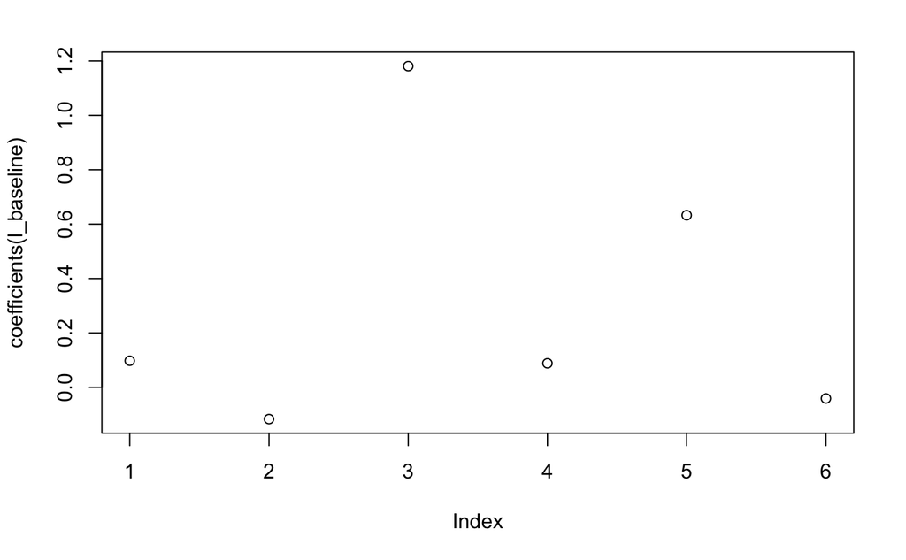

```r
plot(coefficients(l_baseline))
```

### 9.2 Rigid regression

```r
# We convert the data into matrix because the model "glmnet" we are going to use data in matrix form.
# If your dataset contains categorical values, all variables need to be converted into numerical form before converting the dataset into a matrix
x <- data.matrix(train[,-1])
y <- train$diagnosis_result
```

Glmnet parameter alpha=0 for ridge regression. For numerical prediction choose ‘family=gaussian’, for classification ‘family=binomial’.

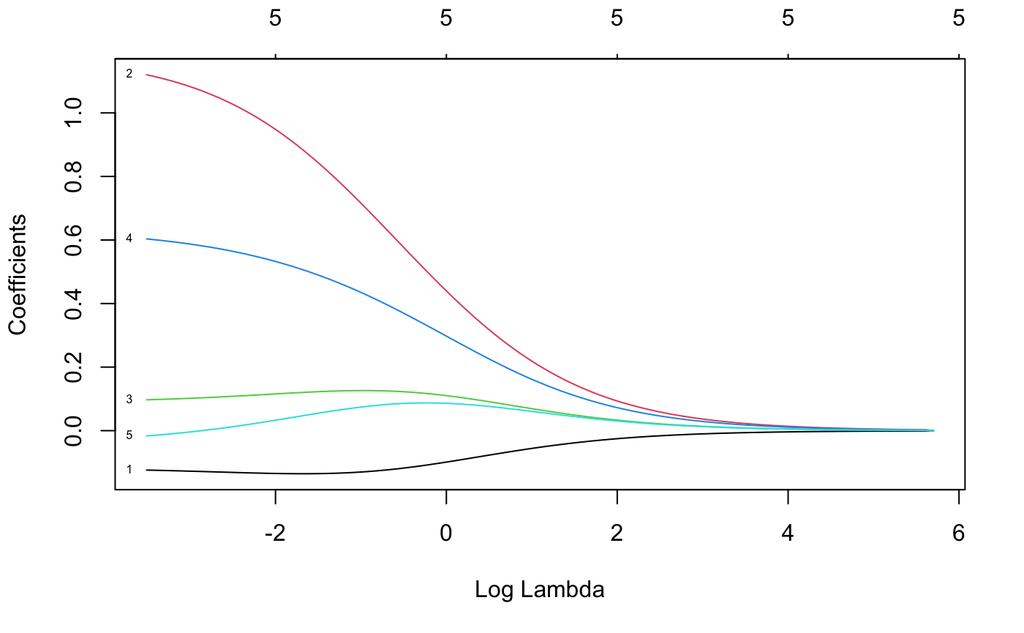

```r
# glmnet by defaut chooses 100 lambda values that are data dependent
l_ridge <- glmnet(x, y, family="gaussian", alpha=0)

# Plot the coefficients with changing lambda
plot(l_ridge, xvar='lambda', label=T)
```

#### Now we need to find the best value for lambda. This may be done using the built-in cross validation of cv.glmnet.

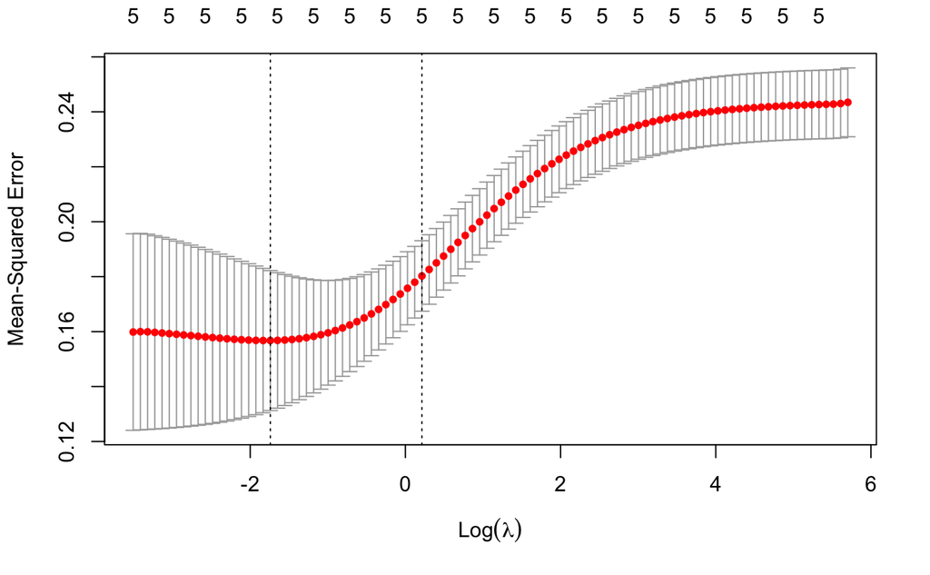

```r
# Now the question is on how to choose lambda value?
# The following plots MSE for various training and validation samples (concept to be covered in cross validation) and various lambdas.
cv_out_ridge = cv.glmnet(x, y, alpha=0)
plot (cv_out_ridge)
```

```r
names(cv_out_ridge)
```

```
 [1] "lambda"     "cvm"        "cvsd"       "cvup"       "cvlo"       "nzero"      "call"
 [8] "name"       "glmnet.fit" "lambda.min" "lambda.1se" "index"
```

#### Two lambda values may be noted. ‘lambda.min’, ‘lambda.1se’- lambda for error within 1 standard deviation.

```r
# lambda_min gives us the lambda value with the lowest error.
lambda_min <- cv_out_ridge$lambda.min
lambda_min
```

```
[1] 0.1754105
```

```r
# lambda_1se gives us the lambda value with sightly higher error but better regularization.
lambda_1se<- cv_out_ridge$lambda.1se
lambda_1se
```

```
[1] 1.237486
```

```r
log(lambda_1se)
```

```
[1] 0.2130821
```

#### Now let us plot the ridge regression output once again

```r
# By increasing the regularization, we reduce the weight value of some variables. Each variable has been given the new weight.
plot(l_ridge, xvar = 'lambda', label=T)
abline(v = log(cv_out_ridge$lambda.1se), col = "red", lty = "dashed")
```

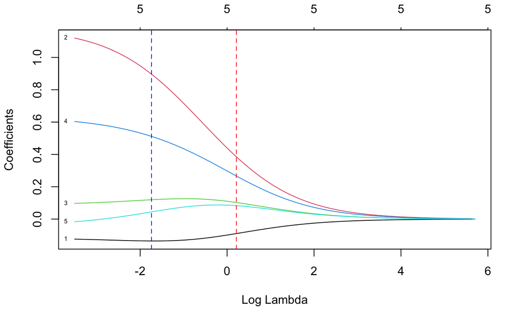

```r
abline(v = log(cv_out_ridge$lambda.min), col = "blue", lty = "dashed")
```

```r
# Now set lambda to one of these values and build the model
l_ridge_final <- glmnet(x, y, family="gaussian", lambda = lambda_1se, alpha=0)
# We can see the correlations listed here.
coef(l_ridge_final)
```

```
6 x 1 sparse Matrix of class "dgCMatrix"
                     s0
(Intercept)  0.38225609
radius      -0.08967697
area         0.38517291
smoothness   0.10268013
compactness  0.26638806
symmetry     0.08293974
```

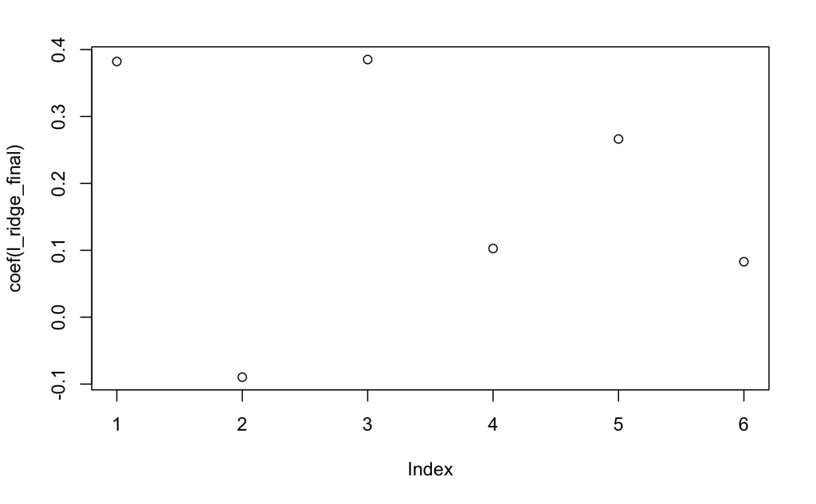

```r
plot(coef(l_ridge_final))
```

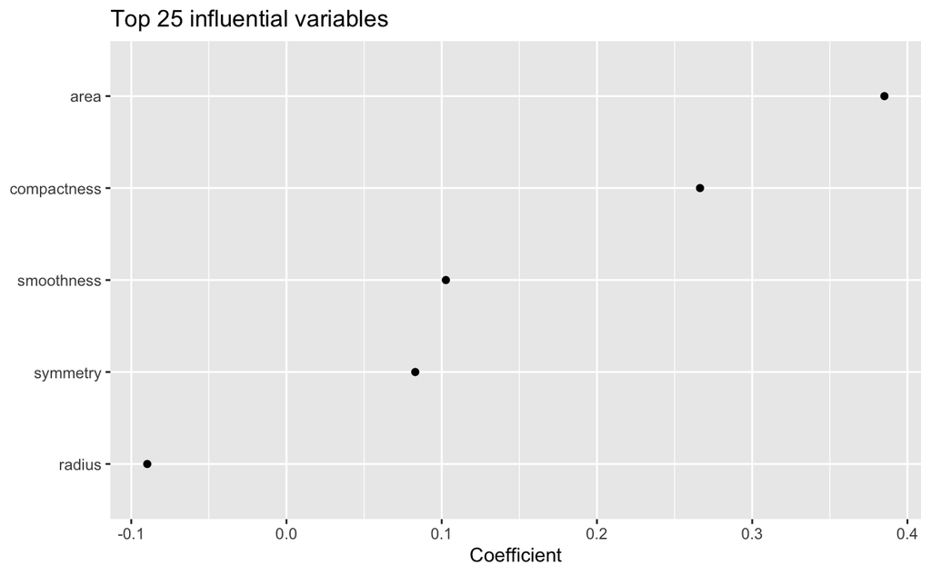

```r
# Alternate plot of the coeffs
coef(l_ridge_final) %>%
  tidy() %>%
  filter(row != "(Intercept)") %>%
  top_n(25, wt = abs(value)) %>%
  ggplot(aes(value, reorder(row, value))) +
  geom_point() +
  ggtitle("Top 25 influential variables") +
  xlab("Coefficient") +
  ylab(NULL)
```

```r
# Prediction with training set
p1 <- predict(l_ridge_final, x) #remeber to use x and not train_data
rmse_l_ridge_final <- sqrt(mean((train$diagnosis_result-p1)^2))
rmse_l_ridge_final
```

```
[1] 0.4131405
```

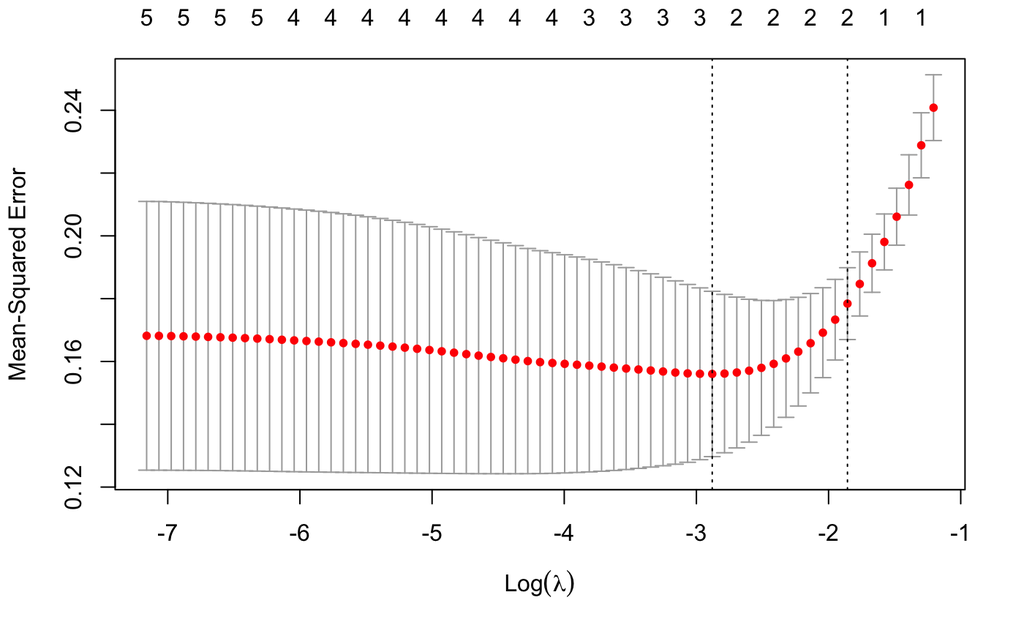

```r
# Repeat the same with lasso regression
cv_out_lasso = cv.glmnet(x, y, alpha = 1)
plot (cv_out_lasso)
```

```r
names(cv_out_lasso)
```

```
 [1] "lambda"     "cvm"        "cvsd"       "cvup"       "cvlo"       "nzero"      "call"
 [8] "name"       "glmnet.fit" "lambda.min" "lambda.1se" "index"
```